```python
from adsy.display import extended_styles
from IPython.display import Image
```

```python
extended_styles()
```

Toggle Input

# Introducing Event-Driven Bertrand Competition

### (Finally)

### Preliminaries

- Profit Maximizing Monopolist
  - Demand Function: $Q = \beta_0 - \beta_1p_1$
  - Profit Function (constant marginal cost): $\pi(p_1) = (\beta_0 - \beta_1p_1)(p_1 -c)$
  - Optimal price : $p_1^*= \frac{\beta_0 + \beta_1c}{2\beta_1}$
- Two firms with imperfect substitutes (2 firms):
  - Demand function facing player $i$: $Q_i = \beta_0 - \beta_1p_i + \beta_2p_{-i}$
  - Firm $i$'s profit : $\pi(p_i) = (\beta_0 - \beta_1p_i + \beta_2p_{-i})(p_i-c)$
  - Firm $i$'s first order condition (best response) : $p_i = \frac{\beta_0 + \beta_2p_{-i}+\beta_1c}{2\beta_1}$
  - (Unique) Nash equilibrium : $p_i^* = \frac{c\beta_1+\beta_0}{2\beta_1-\beta_2}$

### Augmenting to Event Driven

1. Stochastic Demand
   - The demand function can be in 1 of 2 states distinguished by the intercept, $\beta_0$. The demand changes according to an underlying Poisson process with rate $\gamma$. (In terms of an SFT, the market changes its state at a rate of $\gamma$. If market demand is high, then the demand function to firm $i$ is given by $Q_i=\beta_{0,H} - \beta_1p_i + \beta_2p_{-i}$...and similarly for low)
2. Delay in learning demand:
   - When demand changes, firms do not find out until some random time in the future. The rate at which firm $1$ and firm $2$ learn demand is given by $\lambda_1, \lambda_2$. (In terms of an SFT, the market sends out a message randomly to player $1$ and player $2$ at rate $\lambda_1$ and $\lambda_2$. Those messages traverse edges instantly.)
3. Delay in implementation:
   - When a firm learns of the new state of demand, there is a delay in the time their new price is sent to the market. These rates are given by $\mu_1$ and $\mu_2$. (In terms of an SFT, when a firm receives a signal from the market it changes its state to "processing most recent signal from the market and thinking about new price.")

### Player's Strategy Space

- Players choose real number prices in response to observing the market is in the "High" state and the "Low" state. An example strategy might be: "Charge $\$100$ if "High", $\$25$ if "low".
- Let $p_{i,d}$ be player $i$'s price he chooses upon observing that demand is $d$, $d\in\{H, L\}$

### The CTMC

There are $72$ states of the system:

- Each player has $3$ states : $(1)$ Thinking about high signal, $(2)$...low signal, $(3)$ Not thinking.
- The market can be in one of $8$ states:
  - High demand or low demand
  - Player 1's price in the market ($p_{1,H}$ or $p_{1,L}$)
  - Player 2's price in the market...
- The system has a total of $8\times 3 \times 3=72$ states.
- Let $S$ be the set of system states and let $s$ be an element of $S$.

### Expected Utility

- A Player's Utility is the discounted continuous sum of their profits.
  - Suppose from time $T$ to $T+t$, demand for player 1's product is given by $Q_1 = \beta_0 - \beta_1p_1 + \beta_2p_2$ and suppose player 1's price is $\hat{p}_1$ and player 2's price is $\hat{p}_2$, then the amount of discounted reward player $1$ earns from time $T$ to $t+T$ is given by $\int_{T}^{T+t}\text{d}\tau e^{-\alpha\tau}(\beta_0 - \beta_1\hat{p_1} + \beta_2\hat{p_2})(\hat{p}_1-c)$. where $\alpha$ is a discount factor.
- The player's expected utility is then the expectation of his discounted profits where the expectation is taken over the possible trajectories of the CTMC.

### Solving - Expression of expected utility

- Let $\mathbf{g}$ be a $72\times 1$ matrix such that $\mathbf{g}_i$ is the undiscounted per unit-time profit to player $1$ if the system is in state $s_i \in S$.
  - That is, for a system state $s_i$, if player $1$'s price is $\hat{p}_1$, player $2$'s price is $\hat{p}_2$ and the demand intercept is $\hat{\beta}_0$, then $\mathbf{g}_i = (\hat{\beta}_0 - \beta_1 \hat{p}_1 + \beta_2\hat{p}_2)(\hat{p_1}-c)$.
- Let $Q$ be the $72 \times 72$ transition rate matrix that is parameterized by $\gamma, \lambda_1, \lambda_2, \mu_1$ and $\mu_2$.
- It can then be shown that

\begin{equation} [\alpha\mathbf{I} -Q]\mathbf{U} = \mathbf{g}, \end{equation}

where $\mathbf{U}$ is a $72\times 1$ vector and $\mathbf{U}_i$ is the total expected utility to player $1$ given the system starts in state $s_i$.

- This implies

\begin{equation} \mathbf{U}=\mathbf{Ag} \end{equation}

where $A=[\alpha\mathbf{I}-Q]^{-1}$ ($\mathbf{A}$ is known as the resolvent of $Q$ with parameter $\alpha$).

- Given strategies $\mathbf{p_1} = \{p_{1,H}, p_{1,L}\}$ and $\mathbf{p_2} = \{p_{2,H}, p_{2,L}\}$ and supposing the system starts in state $s_1$, then player $1$'s expected utility can be written as:

\begin{equation} EU_1(\mathbf{p}_1, \mathbf{p}_2) = \sum_ja_{1,j}\left[\left(\beta_{0,M_0(s_j)} - \beta_1p_{1, M_1(s_j)} + \beta_2p_{2,M_2(s_j)}\right)(p_{1,M_1(s_j)} -c )\right] \end{equation}

where:

- $a_{1,j}$ is the $j$'th element of row $1$ of the matrix $A$.
- $M_0: S \rightarrow \{H, L\}$ gives the state of demand when the system is in state $s$.
- $M_1 : S \rightarrow \{H, L\}$ gives player $1$'s price in the market when the system is in state $s$.
- $M_2 : S \rightarrow \{H, L\}$ gives player $2$'s price in the market when the system is in state $s$.
- In short, the term in the brackets is an item in $g$ for a given strategy of player $1$ and player $2$.

### Solving - First Order Conditions

- For player 1, the first order conditions are given by:

\begin{equation} \frac{\text{d}EU_1}{\text{d}p_{1,H}} =\sum_ja_{1,j}\left[\left(\beta_{0,M_0(s_j)} - 2\beta_1p_{1, M_1(s_j)} + \beta_2p_{2,M_2(s_j)} +\beta_1c\right)\mathbb{1}\left[M_1(s_j) = H \right]\right] \end{equation}

and

\begin{equation} \frac{\text{d}EU_1}{\text{d}p_{1,L}} =\sum_ja_{1,j}\left[\left(\beta_{0,M_0(s_j)} - 2\beta_1p_{1, M_1(s_j)} + \beta_2p_{2,M_2(s_j)} +\beta_1c\right)\mathbb{1}\left[M_1(s_j) = L \right]\right] \end{equation}

where $\mathbb{1}$ is the indicator function that takes the value of $1$ when its argument evaluates to true. Note that from these, we can get player $1$'s best response functions of the form

\begin{align} p_{1,H} = \theta_0 + \theta_1p_{2,H} + \theta_2p_{2,L} \\ p_{1,L} = \theta_3 + \theta_4p_{2,H} + \theta_5p_{2,L} \end{align}

and by symmetry

\begin{align} p_{2,H} = \theta_6 + \theta_7p_{1,H} + \theta_8p_{1,L} \\ p_{2,L} = \theta_9 + \theta_{10}p_{1,H} + \theta_{11}p_{1,L} \end{align}

where all of the $\theta$ parameters are functions of the elements of $\mathbf{A}$ (which is a function of exogenous rate parameters), $\beta_{0,H}, \beta_{0,L}, \beta_1$ and $\beta_2$. The Nash equilibrium is just the solution to this system of 4 linear equations.

# Results

- How do the player's responses change with respect to changes in $\lambda_1$ and $\lambda_2$, assuming that they can react very quickly.
- Parameters:
  - $\beta_1 = 4$
  - $\beta_2 = 2$
  - $\gamma=5$
  - $c=2$
  - $\beta_{0,H}=300$
  - $\beta_{0,L}=100$
  - $\mu_1, \mu_2 = \infty$

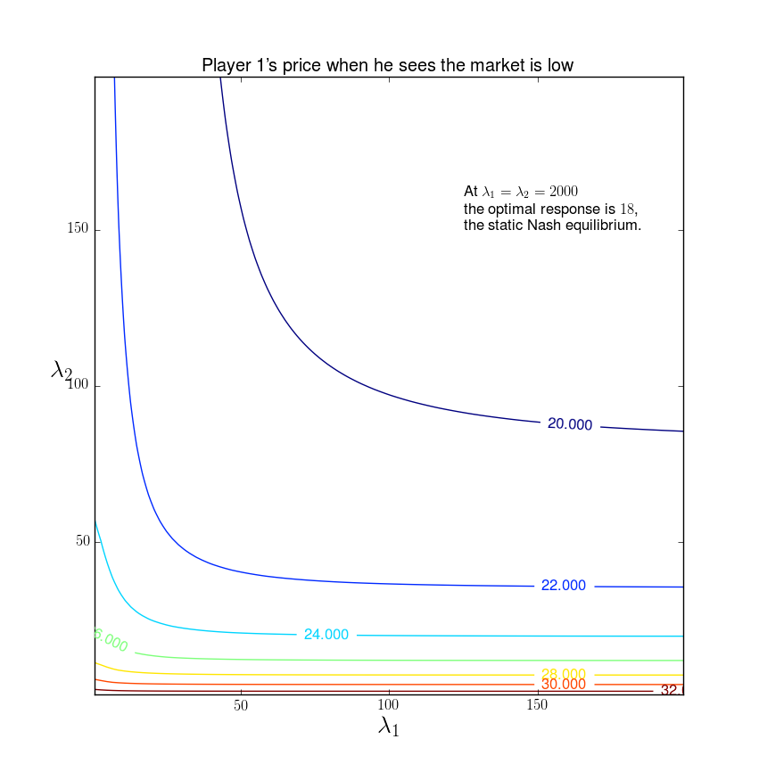

```python
Image("./siglow.png")
```

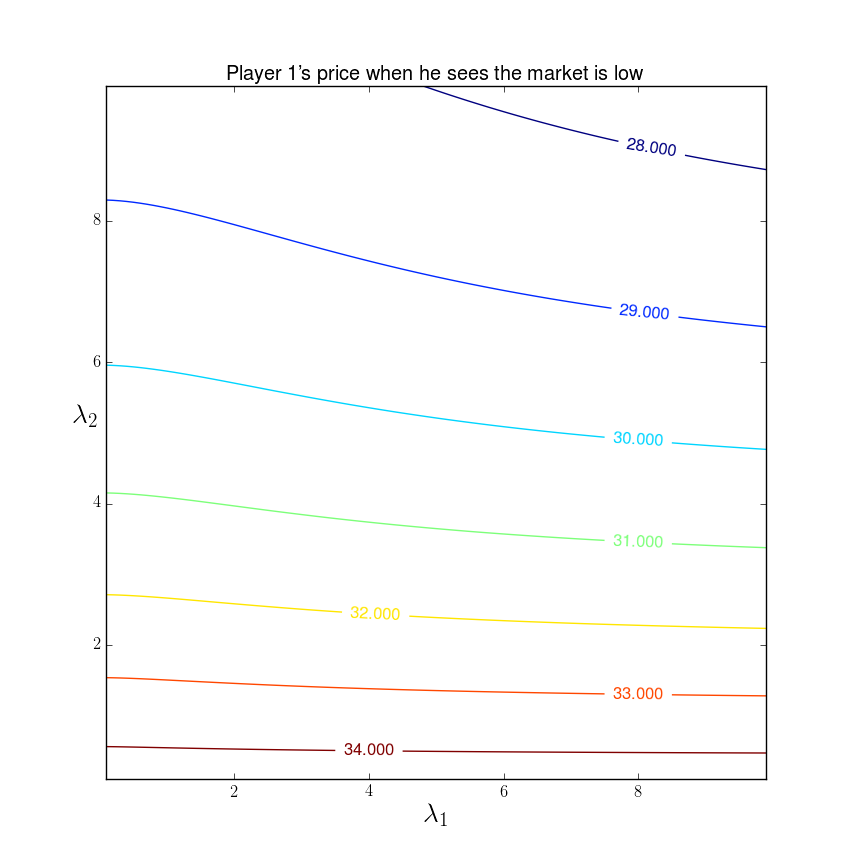

```python
Image("./siglowzoomin.png")
```

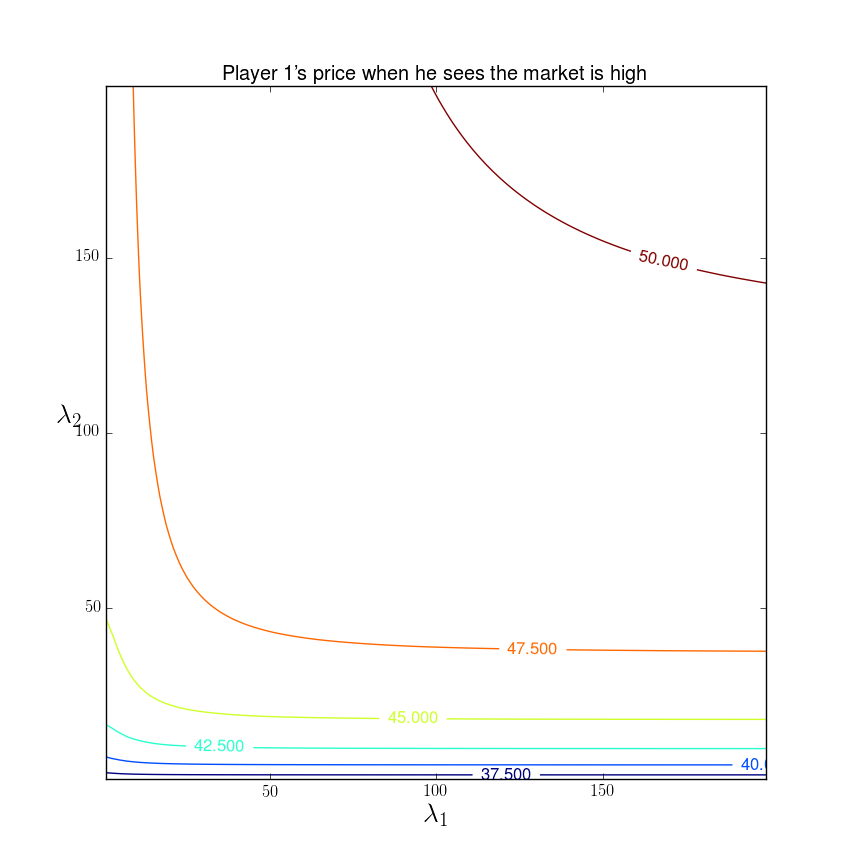

```python
Image("./sighigh.png")
```

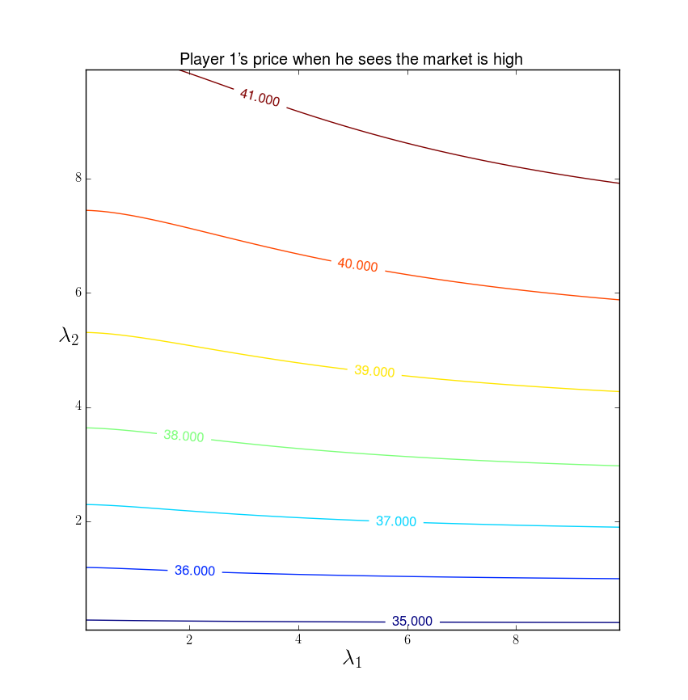

```python
Image("./sighighzoomin.png")
```

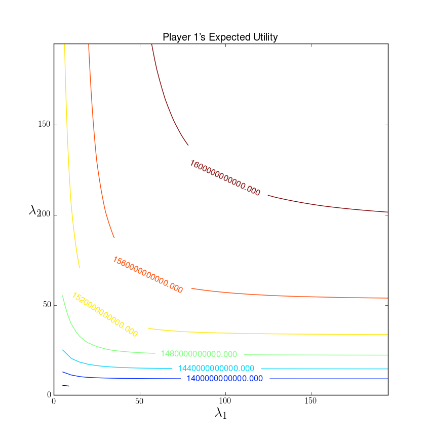

```python
Image("./p1eu.png")
```

### Next Steps:

- More experiments (any suggestions?)
- Prettier plots (any suggestions?)
- Have players receive price information re: other players price.
  - With this addition we can also represent Stackelberg-like scenarios.
- Try and get the exact dependence of the Nash equilibrium strategies on the rate parameters.